# R Notebook

# Plot existing counts

## tell it not to change anything

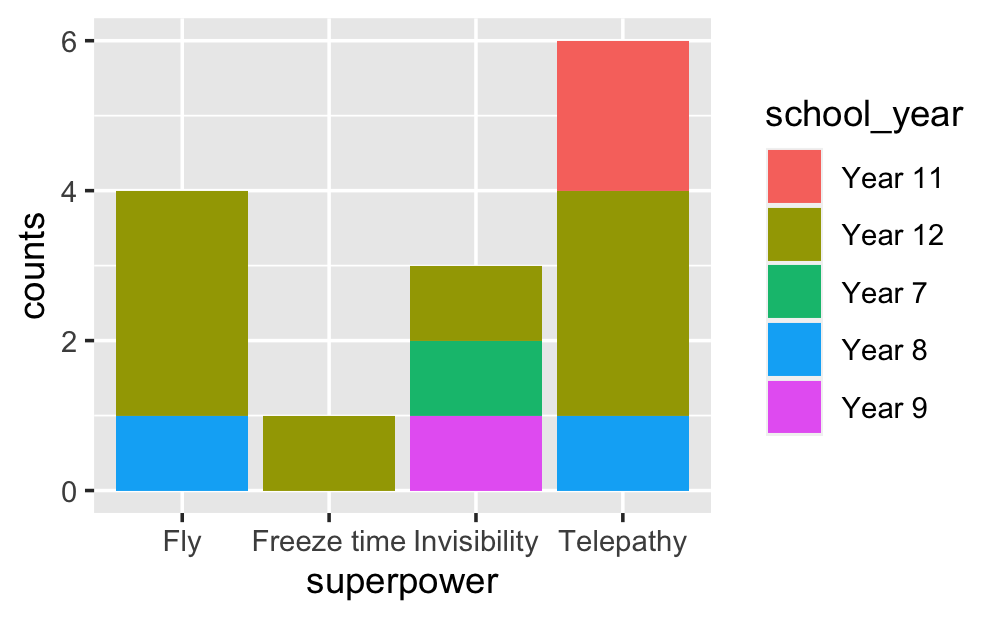

```r
ggplot(count_data) +
  aes(x = superpower, y = counts, fill = school_year) +
  geom_bar(stat = "identity")
```

## use a different shape

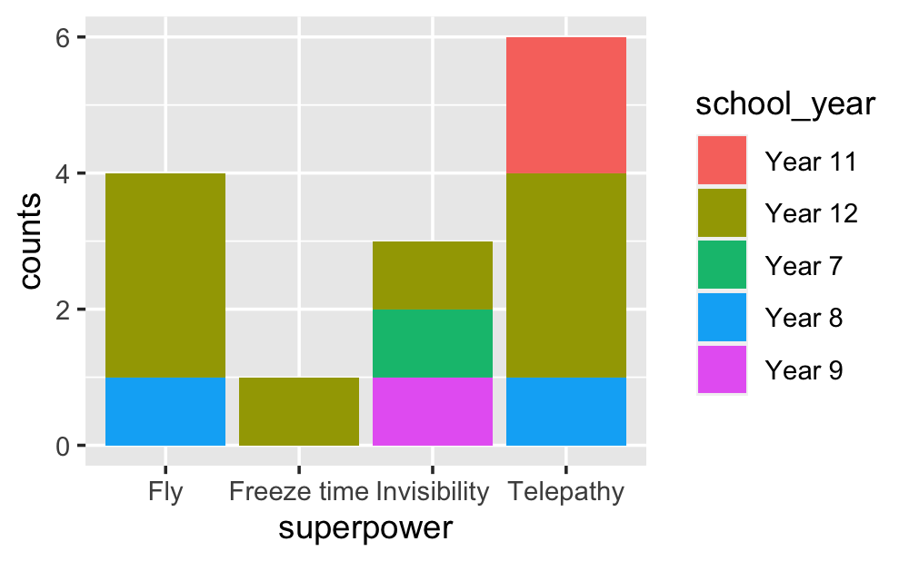

```r
ggplot(count_data) +
  aes(x = superpower, y = counts, fill = school_year) +
  geom_col()
```

# Labels

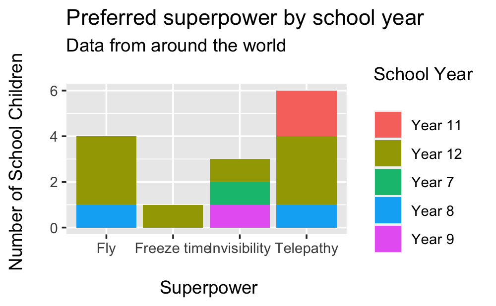

```r
ggplot(students) +
  aes(x = superpower, fill = school_year) +
  geom_bar() +
  labs(
    x = "\n Superpower",
    y = "Number of School Children \n",
    title = "Preferred superpower by school year",
    subtitle = "Data from around the world \n",
    fill = "School Year \n"
  )
```

# Task

```r
olympics_overall_medals <- read_csv("data/olympics_overall_medals.csv")
```

```r
top_10 <- olympics_overall_medals %>%
  filter(season == "Summer", medal == "Gold") %>%
  arrange(desc(count)) %>%
  top_n(10)
```

Create an informative plot that plots the count of medals by team. Write down an explanation of what the plot shows.

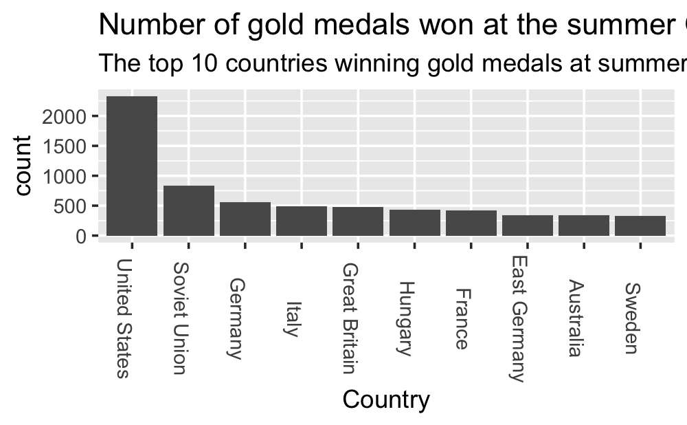

```r
ggplot(top_10) +
  aes(x = reorder(team, -count), y = count) +
  geom_col() +
  labs(
    x = "Country",
    title = "Number of gold medals won at the summer Olympics",
    subtitle = "The top 10 countries winning gold medals at summer Olympics"
  ) +
  theme(axis.text.x = element_text(angle = -90))
```

# Layers

```r
library(janitor)
data("ChickWeight")
chick_weight <- clean_names(ChickWeight)
head(chick_weight)
```

|  | weight | time | chick | diet |
| --- | --- | --- | --- | --- |
| 1 | 42 | 0 | 1 | 1 |
| 2 | 51 | 2 | 1 | 1 |
| 3 | 59 | 4 | 1 | 1 |
| 4 | 64 | 6 | 1 | 1 |
| 5 | 76 | 8 | 1 | 1 |
| 6 | 93 | 10 | 1 | 1 |

```r
rm(ChickWeight)
```

## Chick weights over time

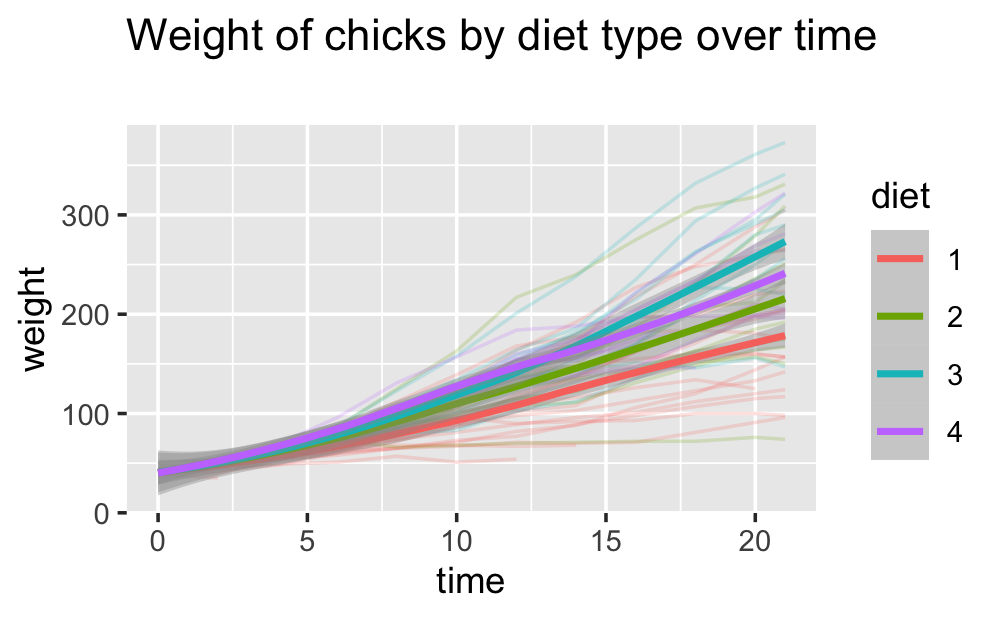

```r
ggplot(chick_weight) +
  aes(x = time, y = weight, colour = diet) +
  geom_line(aes(group = chick), alpha = 0.2) +
#  geom_point(alpha = 0.3) +
  geom_smooth() +
  labs(
    title = "Weight of chicks by diet type over time \n"
  )
```

#Task

Task 1 - 10 mins Using the students dataset: Use geom_point to make a scatter graph, with the height of students on the x-axis and their reaction time of the y axis. Make all the points blue. For geom_bar, the colour of the bar is controlled by fill, but for geom_point the colour of the points are controlled by colour.

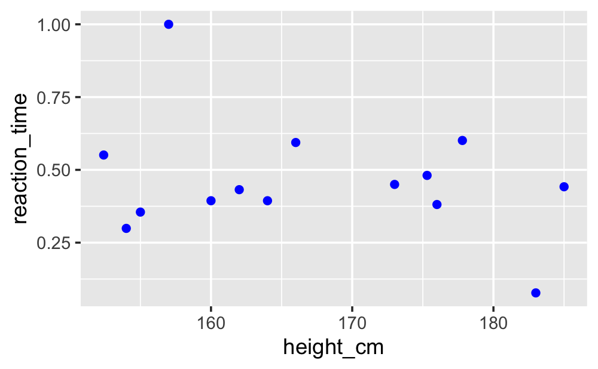

Make the colour of the points depend on the superpower the student wishes they had. Change the position of the plot to jitter (using the position argument in geom_point). What do you see? Jitter spreads out dots which cluster so you can see each point even if they are identical (or overlayed)

Write down what the graph tells you overall.

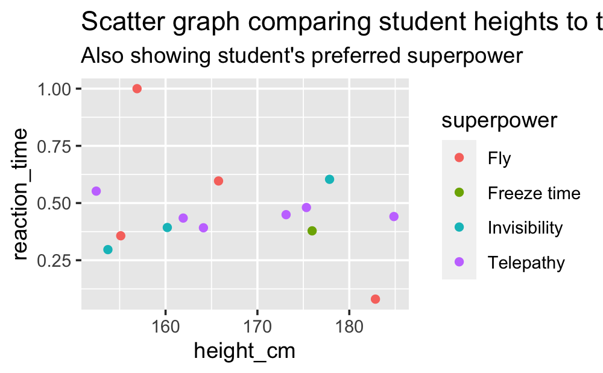

Task 2 - 10 mins Let’s load the dataset pets: pets <- read_csv(“data/pets.csv”) Create a labelled scatter plot, of pet age vs. weight, with the following 5 mapping/aesthetics. For items 3-5 you may want to look at the help file of ?geom_point and read about different aesthetics: We want age of the x-axis and weight on the y axis We want the points the be different colours depending on the gender of the pet We want different shapes depending on the type of animal We want all the points to be bigger than normal (size 4). We also want labels with the pets names next to every point

```r
pets <- read_csv("data/pets.csv")
```

[figure not shown]

```r
ggsave("myplot.png")
```